# ML Project

Bill Schroeder

November 8, 2015

## 1.0 Executive Summary

Our goal is to predict how well a subject performed an excersise based on data recieved from a set of accelerometers the subject wore while performing the excercise. Specifically accelerometers on the belt, forearm, arm, and dumbell for 6 participants. More information on the dataset is available from the website: http://groupware.les.inf.puc-rio.br/har (see the section on the Weight Lifting Exercise Dataset).

In order to predict how the subject performed, we select an ML model, cross validate, calculate the expected out of sample error, and use the ML prediction model to predict 20 different test cases.

## 2.0 Data Exploration

### 2.1 Examine the data and review metadata

Metadata is avialble on the website http://groupware.les.inf.puc-rio.br/har. Review the size, structure, and quality of the data.

```r
# load the training data - https://d396qusza40orc.cloudfront.net/predmachlearn/pml-training.csv
if(!file.exists("pml-training.csv")){
  download.file("http://d396qusza40orc.cloudfront.net/predmachlearn/pml-training.csv",
                "pml-training.csv")
}
rawTrainingData <- read.csv( "pml-training.csv", header=TRUE, sep=",")


# Load the test data - https://d396qusza40orc.cloudfront.net/predmachlearn/pml-testing.csv
if(!file.exists("pml-testing.csv")){
  download.file("http://d396qusza40orc.cloudfront.net/predmachlearn/pml-testing.csv",
                "pml-testing.csv")
}
rawTestData <- read.csv( "pml-testing.csv", header=TRUE, sep=",")
```

### 2.2 Examine the amount of test data relative to training data

Determine what to preprocess and clean. See Apendix for additional data exploration.

```r
# perform some exploratory data analysis
dim( rawTrainingData )
```

```
## [1] 19622   160
```

```r
dim( rawTestData )
```

```
## [1]  20 160
```

```r
# calculate how much test data we have
rawTraindataDim <- dim( rawTrainingData )
rawTestdataDim <- dim( rawTestData )

# print("Percent of raw training vs raw test data")
paste(round(( rawTestdataDim[1]/ rawTraindataDim[1])*100,digits=1),"%",sep="")
```

```
## [1] "0.1%"
```

## 3.0 Tidying and Preprocessing Data

```r
# clean and tidy the data

# seed the random generation for reproducible results
set.seed(123)

# check for ML required packages
if("caret" %in% rownames(installed.packages() ) == FALSE){
  install.packages("caret")
  install.packages("randomForest")
}
library(caret)
# remove the attribute (column) if there is more than 1/2 the values missing
dropVector <- c()
for(i in 1:length( rawTrainingData ) ) {
  if( sum( is.na( rawTrainingData[ ,i] ) )/nrow( rawTrainingData ) > 0.5 ){
    dropVector <- c(dropVector, i)
  }
}
tidy_trainingData <- rawTrainingData
tidy_trainingData <- tidy_trainingData[,-dropVector,drop=FALSE]
rawTestData <- rawTestData[,-dropVector,drop=FALSE]

# eliminate the irrelevant data - also getting in the way of model performance
tidy_trainingData <- tidy_trainingData[, -c(1:5)]
rawTestData <- rawTestData[ ,  -c(1:5)]

# print("Dimensions of NA cleaned data")
dim( tidy_trainingData )
```

```
## [1] 19622    88
```

```r
# remove predictors that have near zero variance since they do not add predictive value
nzv_predictors <- nearZeroVar( tidy_trainingData )
tidy_trainingData <- tidy_trainingData[ , -nzv_predictors]
rawTestData <- rawTestData[ , -nzv_predictors]

# print("Dimensions of near zero variance cleaned data")
dim( tidy_trainingData )
```

```
## [1] 19622    54
```

```r
dim( rawTestData )
```

```
## [1] 20 54
```

```r
# print("Percent of attributes of cleaned vs raw data")
paste(round(( dim(tidy_trainingData)[2]/dim( rawTrainingData)[2] )*100,digits=1),"%",sep="")
```

```
## [1] "33.8%"
```

## 4.0 Cross Validation

In order to generate an ML model we first make a study design decison to divide the initial training set into the recommended 60/40 split. We will use 60% of the training data to train, 40% to test and use the provided testing data to validate the model. (NOTE - this turns out to be redundant because of the OOB technique used in random forest algorithm)

```r
# partitian the training data set into training and testing sets
inTrain <- createDataPartition( y=tidy_trainingData$classe, p=0.6, list=FALSE )
tidy_trainingSubset <- tidy_trainingData[inTrain, ]
tidy_testingSubset <- tidy_trainingData[-inTrain, ]
dim(tidy_trainingSubset);dim(tidy_testingSubset)
```

```
## [1] 11776    54
```

```
## [1] 7846   54
```

## 5.0 Model Generation

Select random Forests to mitigate the problems of high variance and high bias by averaging to balance between the two extremes. Based on matrix at http://www.dataschool.io/comparing-supervised-learning-algorithms/, select the Random Forest (RF) technique.

```r
# check for ML required packages
if("rattle" %in% rownames(installed.packages() ) == FALSE){
  install.packages("rattle")
}
library(rattle)
# select random forest model because of its performance in general predicion to build model
library(randomForest)
modelFit <- randomForest( classe~.,data=tidy_trainingSubset, method="class" )
modelFit
```

```
##
## Call:
##  randomForest(formula = classe ~ ., data = tidy_trainingSubset,      method = "class")
##                Type of random forest: classification
##                      Number of trees: 500
## No. of variables tried at each split: 7
##
##         OOB estimate of  error rate: 0.35%
## Confusion matrix:
##      A    B    C    D    E  class.error
## A 3347    0    0    0    1 0.0002986858
## B    4 2274    1    0    0 0.0021939447
## C    0   14 2039    1    0 0.0073028238
## D    0    0   14 1914    2 0.0082901554
## E    0    0    0    4 2161 0.0018475751
```

### 5.1 Expected out sample error

We calculated the expected out of sample error two differnt ways. We used the cross validation process to split the original training data into a training and test set and then ran our trained model on the test cross validation partition and calculated the error rate. We also used the OOB error rate generated from the random forest model since the algorithm effectively does internal cross validation by reserving or “bagging” a set of the data during training and then calculating the error rate on the reserved data as OOB error. Both techniques came up with similar out of sample error rates;

**The OOB error is 0.35%**

The estimated error rate using the test samples set aside in the cross-validation step are shown in the output of The confustion matrix. The confusion matrix shows The accuracy as 0.997. The estimated error rate is 1 - accuracy.

**The cross validated out of smaple error is 0.3%**

[output not shown]

## 6.0 Summary and Predictions of Study

The goal of this project was to select a supervised machine learning algorithm that could accurately predict the “classe” variable from a dataset containing information on excercise sessions. In this context “classe” refers to the quality of the excercise that was performed.

### 6.1 Prediction algorithm and helper function to write each prediction to a text file

```r
# use the model to predict the cross validated testing data
predictFromTestData <- predict( modelFit, newdata=rawTestData )


#
pml_write_files = function(x){
  n = length(x)
  for(i in 1:n){
    filename = paste0("problem_id_",i,".txt")
    write.table(x[i],file=filename,quote=FALSE,row.names=FALSE,col.names=FALSE)
  }
}

pml_write_files( predictFromTestData )
```

## 7.0 Appendix

```r
# look at raw data
str( rawTrainingData)
```

```
## 'data.frame':    19622 obs. of  160 variables:
##  $ X                       : int  1 2 3 4 5 6 7 8 9 10 ...
##  $ user_name               : Factor w/ 6 levels "adelmo","carlitos",..: 2 2 2 2 2 2 2 2 2 2 ...
##  $ raw_timestamp_part_1    : int  1323084231 1323084231 1323084231 1323084232 1323084232 1323084232 1323084232 1323084232 1323084232 1323084232 ...
##  $ raw_timestamp_part_2    : int  788290 808298 820366 120339 196328 304277 368296 440390 484323 484434 ...
##  $ cvtd_timestamp          : Factor w/ 20 levels "02/12/2011 13:32",..: 9 9 9 9 9 9 9 9 9 9 ...
##  $ new_window              : Factor w/ 2 levels "no","yes": 1 1 1 1 1 1 1 1 1 1 ...
##  $ num_window              : int  11 11 11 12 12 12 12 12 12 12 ...
##  $ roll_belt               : num  1.41 1.41 1.42 1.48 1.48 1.45 1.42 1.42 1.43 1.45 ...
##  $ pitch_belt              : num  8.07 8.07 8.07 8.05 8.07 8.06 8.09 8.13 8.16 8.17 ...
##  $ yaw_belt                : num  -94.4 -94.4 -94.4 -94.4 -94.4 -94.4 -94.4 -94.4 -94.4 -94.4 ...
##  $ total_accel_belt        : int  3 3 3 3 3 3 3 3 3 3 ...
##  $ kurtosis_roll_belt      : Factor w/ 397 levels "","-0.016850",..: 1 1 1 1 1 1 1 1 1 1 ...
##  $ kurtosis_picth_belt     : Factor w/ 317 levels "","-0.021887",..: 1 1 1 1 1 1 1 1 1 1 ...
##  $ kurtosis_yaw_belt       : Factor w/ 2 levels "","#DIV/0!": 1 1 1 1 1 1 1 1 1 1 ...
```

[output cut: 86 more lines]

```r
str( rawTestData)
```

```
## 'data.frame':    20 obs. of  54 variables:
##  $ num_window          : int  74 431 439 194 235 504 485 440 323 664 ...
##  $ roll_belt           : num  123 1.02 0.87 125 1.35 -5.92 1.2 0.43 0.93 114 ...
##  $ pitch_belt          : num  27 4.87 1.82 -41.6 3.33 1.59 4.44 4.15 6.72 22.4 ...
##  $ yaw_belt            : num  -4.75 -88.9 -88.5 162 -88.6 -87.7 -87.3 -88.5 -93.7 -13.1 ...
##  $ total_accel_belt    : int  20 4 5 17 3 4 4 4 4 18 ...
##  $ gyros_belt_x        : num  -0.5 -0.06 0.05 0.11 0.03 0.1 -0.06 -0.18 0.1 0.14 ...
##  $ gyros_belt_y        : num  -0.02 -0.02 0.02 0.11 0.02 0.05 0 -0.02 0 0.11 ...
##  $ gyros_belt_z        : num  -0.46 -0.07 0.03 -0.16 0 -0.13 0 -0.03 -0.02 -0.16 ...
##  $ accel_belt_x        : int  -38 -13 1 46 -8 -11 -14 -10 -15 -25 ...
##  $ accel_belt_y        : int  69 11 -1 45 4 -16 2 -2 1 63 ...
##  $ accel_belt_z        : int  -179 39 49 -156 27 38 35 42 32 -158 ...
##  $ magnet_belt_x       : int  -13 43 29 169 33 31 50 39 -6 10 ...
##  $ magnet_belt_y       : int  581 636 631 608 566 638 622 635 600 601 ...
##  $ magnet_belt_z       : int  -382 -309 -312 -304 -418 -291 -315 -305 -302 -330 ...
```

[output cut: 40 more lines]

```r
# look at data after cleansing
summary(tidy_trainingData)
```

```
##    num_window      roll_belt        pitch_belt          yaw_belt
##  Min.   :  1.0   Min.   :-28.90   Min.   :-55.8000   Min.   :-180.00
##  1st Qu.:222.0   1st Qu.:  1.10   1st Qu.:  1.7600   1st Qu.: -88.30
##  Median :424.0   Median :113.00   Median :  5.2800   Median : -13.00
##  Mean   :430.6   Mean   : 64.41   Mean   :  0.3053   Mean   : -11.21
##  3rd Qu.:644.0   3rd Qu.:123.00   3rd Qu.: 14.9000   3rd Qu.:  12.90
##  Max.   :864.0   Max.   :162.00   Max.   : 60.3000   Max.   : 179.00
##  total_accel_belt  gyros_belt_x        gyros_belt_y       gyros_belt_z
##  Min.   : 0.00    Min.   :-1.040000   Min.   :-0.64000   Min.   :-1.4600
##  1st Qu.: 3.00    1st Qu.:-0.030000   1st Qu.: 0.00000   1st Qu.:-0.2000
##  Median :17.00    Median : 0.030000   Median : 0.02000   Median :-0.1000
##  Mean   :11.31    Mean   :-0.005592   Mean   : 0.03959   Mean   :-0.1305
##  3rd Qu.:18.00    3rd Qu.: 0.110000   3rd Qu.: 0.11000   3rd Qu.:-0.0200
##  Max.   :29.00    Max.   : 2.220000   Max.   : 0.64000   Max.   : 1.6200
##   accel_belt_x       accel_belt_y     accel_belt_z     magnet_belt_x
##  Min.   :-120.000   Min.   :-69.00   Min.   :-275.00   Min.   :-52.0
##  1st Qu.: -21.000   1st Qu.:  3.00   1st Qu.:-162.00   1st Qu.:  9.0
##  Median : -15.000   Median : 35.00   Median :-152.00   Median : 35.0
##  Mean   :  -5.595   Mean   : 30.15   Mean   : -72.59   Mean   : 55.6
##  3rd Qu.:  -5.000   3rd Qu.: 61.00   3rd Qu.:  27.00   3rd Qu.: 59.0
##  Max.   :  85.000   Max.   :164.00   Max.   : 105.00   Max.   :485.0
##  magnet_belt_y   magnet_belt_z       roll_arm         pitch_arm
##  Min.   :354.0   Min.   :-623.0   Min.   :-180.00   Min.   :-88.800
##  1st Qu.:581.0   1st Qu.:-375.0   1st Qu.: -31.77   1st Qu.:-25.900
##  Median :601.0   Median :-320.0   Median :   0.00   Median :  0.000
##  Mean   :593.7   Mean   :-345.5   Mean   :  17.83   Mean   : -4.612
##  3rd Qu.:610.0   3rd Qu.:-306.0   3rd Qu.:  77.30   3rd Qu.: 11.200
##  Max.   :673.0   Max.   : 293.0   Max.   : 180.00   Max.   : 88.500
##     yaw_arm          total_accel_arm  gyros_arm_x        gyros_arm_y
##  Min.   :-180.0000   Min.   : 1.00   Min.   :-6.37000   Min.   :-3.4400
##  1st Qu.: -43.1000   1st Qu.:17.00   1st Qu.:-1.33000   1st Qu.:-0.8000
##  Median :   0.0000   Median :27.00   Median : 0.08000   Median :-0.2400
##  Mean   :  -0.6188   Mean   :25.51   Mean   : 0.04277   Mean   :-0.2571
##  3rd Qu.:  45.8750   3rd Qu.:33.00   3rd Qu.: 1.57000   3rd Qu.: 0.1400
##  Max.   : 180.0000   Max.   :66.00   Max.   : 4.87000   Max.   : 2.8400
##   gyros_arm_z       accel_arm_x       accel_arm_y      accel_arm_z
##  Min.   :-2.3300   Min.   :-404.00   Min.   :-318.0   Min.   :-636.00
##  1st Qu.:-0.0700   1st Qu.:-242.00   1st Qu.: -54.0   1st Qu.:-143.00
##  Median : 0.2300   Median : -44.00   Median :  14.0   Median : -47.00
##  Mean   : 0.2695   Mean   : -60.24   Mean   :  32.6   Mean   : -71.25
```

[output cut: 50 more lines]

```
##  Max.   :311.00000   Max.   :231.0000   Max.   : 477.00   Max.   : 923.0
##  accel_forearm_z   magnet_forearm_x  magnet_forearm_y magnet_forearm_z
##  Min.   :-446.00   Min.   :-1280.0   Min.   :-896.0   Min.   :-973.0
##  1st Qu.:-182.00   1st Qu.: -616.0   1st Qu.:   2.0   1st Qu.: 191.0
##  Median : -39.00   Median : -378.0   Median : 591.0   Median : 511.0
##  Mean   : -55.29   Mean   : -312.6   Mean   : 380.1   Mean   : 393.6
##  3rd Qu.:  26.00   3rd Qu.:  -73.0   3rd Qu.: 737.0   3rd Qu.: 653.0
##  Max.   : 291.00   Max.   :  672.0   Max.   :1480.0   Max.   :1090.0
##  classe
##  A:5580
##  B:3797
##  C:3422
##  D:3216
##  E:3607
##
```

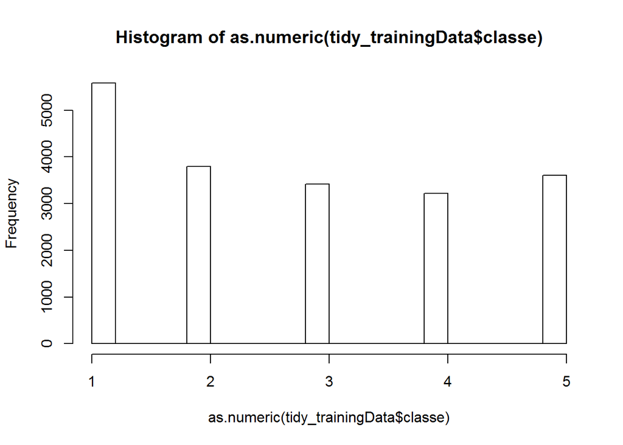

```r
#firstFit <- train( classe~., method="rpart", data=tidy_trainingSubset )
#print(firstFit$finalModel)
#plot(firstFit$finalModel, uniform=TRUE, main = "Classifying Main Predictors" )
#text(firstFit$finalModel, use.n=TRUE, all=TRUE, cex = .8)
#fancyRpartPlot( firstFit$finalPlot )

# Is the classifier variable normally distributed?
hist( as.numeric(tidy_trainingData$classe ) )
```